# Analysis of Data Science Salaries

Bishal Paul

15-04-2024

# Introduction

The goal of this project is to analyze a dataset of data science salaries to understand the key factors that influence compensation. We will perform a thorough exploratory data analysis (EDA), clean the data, and then build several predictive models to estimate salary based on job attributes. The models include a baseline Linear Regression, Ridge, Lasso, and Elastic Net regression. Finally, we will compare their performance and suggest potential avenues for further improvement.

# 1. Setup and Data Loading

## 1.1. Load Libraries

First, we load all the necessary R packages for data manipulation, visualization, and modeling.

```r
# For data manipulation and visualization
library(tidyverse)
# For advanced plots
library(patchwork)
# For modeling and data splitting
library(caret)
# For Ridge, Lasso, and Elastic Net models
library(glmnet)
# For VIF calculation
library(car)
#For XGBoost Model
library(xgboost)
```

## 1.2. Load Data

We load the dataset and clean the column names for better readability and easier use in R.

```r
# Load the dataset
salary_data <- read.csv("Data_Science_Fields_Salary_Categorization.csv")

# Clean column names
colnames(salary_data) <- c("id", "working_year", "designation", "experience",
                           "employment_status", "salary_in_rupees", "employee_location",
                           "company_location", "company_size", "remote_working_ratio")

# Remove the unnecessary ID column
salary_data <- salary_data %>% select(-id)

# Display the first few rows
head(salary_data)
```

```
##   working_year                designation experience employment_status
## 1         2020             Data Scientist         MI                FT
## 2         2020 Machine Learning Scientist         SE                FT
## 3         2020          Big Data Engineer         SE                FT
## 4         2020       Product Data Analyst         MI                FT
## 5         2020  Machine Learning Engineer         SE                FT
## 6         2020               Data Analyst         EN                FT
##   salary_in_rupees employee_location company_location company_size
## 1     6,352,272.00                DE               DE            L
## 2    20,688,070.00                JP               JP            S
## 3     8,674,985.00                GB               GB            M
## 4     1,591,390.00                HN               HN            S
## 5    11,935,425.00                US               US            L
## 6     5,729,004.00                US               US            L
##   remote_working_ratio
## 1                    0
## 2                    0
## 3                   50
## 4                    0
## 5                   50
## 6                  100
```

# 2. Data Cleaning and Preprocessing

## 2.1. Initial Data Inspection

We start by checking the structure and summary of the data to identify data types and potential issues.

```r
# Check the structure of the dataframe
str(salary_data)
```

```
## 'data.frame':    607 obs. of  9 variables:
##  $ working_year        : int  2020 2020 2020 2020 2020 2020 2020 2020 2020 2020 ...
##  $ designation         : chr  "Data Scientist" "Machine Learning Scientist" "Big Data Engineer" "Product Data Analyst" ...
##  $ experience          : chr  "MI" "SE" "SE" "MI" ...
##  $ employment_status   : chr  "FT" "FT" "FT" "FT" ...
##  $ salary_in_rupees    : chr  "6,352,272.00" "20,688,070.00" "8,674,985.00" "1,591,390.00" ...
##  $ employee_location   : chr  "DE" "JP" "GB" "HN" ...
##  $ company_location    : chr  "DE" "JP" "GB" "HN" ...
##  $ company_size        : chr  "L" "S" "M" "S" ...
##  $ remote_working_ratio: int  0 0 50 0 50 100 100 50 100 50 ...
```

The `salary_in_rupees` column is incorrectly typed as a character (`chr`) due to commas. We need to convert it to a numeric type.

## 2.2. Clean Salary Column

We remove the commas from the salary column and convert it to a numeric format.

```r
salary_data$salary <- as.numeric(gsub(",", "", salary_data$salary_in_rupees))

# We can now remove the original character column
salary_data <- salary_data %>% select(-salary_in_rupees)
```

## 2.3. Convert Characters to Factors

Categorical variables are stored as characters. For statistical modeling and plotting, it’s better to convert them into factors.

```r
salary_data <- salary_data %>%
  mutate(across(where(is.character), as.factor)) %>%
  mutate(working_year = as.factor(working_year),
         remote_working_ratio = as.factor(remote_working_ratio))

# Verify the changes
str(salary_data)
```

```
## 'data.frame':    607 obs. of  9 variables:
##  $ working_year        : Factor w/ 3 levels "2020","2021",..: 1 1 1 1 1 1 1 1 1 1 ...
##  $ designation         : Factor w/ 50 levels "3D Computer Vision Researcher",..: 23 41 8 48 38 13 35 23 9 34 ...
##  $ experience          : Factor w/ 4 levels "EN","EX","MI",..: 3 4 4 3 4 1 4 3 3 4 ...
##  $ employment_status   : Factor w/ 4 levels "CT","FL","FT",..: 3 3 3 3 3 3 3 3 3 3 ...
##  $ employee_location   : Factor w/ 57 levels "AE","AR","AT",..: 15 33 21 24 56 56 56 26 56 42 ...
##  $ company_location    : Factor w/ 50 levels "AE","AS","AT",..: 13 30 19 21 49 49 49 23 49 39 ...
##  $ company_size        : Factor w/ 3 levels "L","M","S": 1 3 2 3 1 1 3 1 1 3 ...
##  $ remote_working_ratio: Factor w/ 3 levels "0","50","100": 1 1 2 1 2 3 3 2 3 2 ...
##  $ salary              : num  6352272 20688070 8674985 1591390 11935425 ...
```

# 3. Exploratory Data Analysis (EDA)

## 3.1. Salary Distribution

Let’s first examine the distribution of salaries.

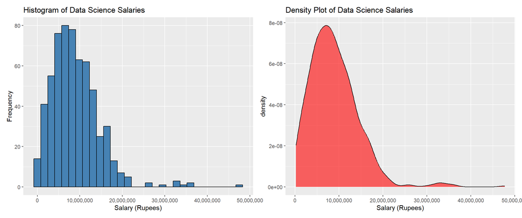

```r
p1 <- ggplot(salary_data, aes(x = salary)) +
  geom_histogram(bins = 30, fill = "steelblue", color = "black") +
  scale_x_continuous(labels = scales::comma) +
  labs(title = "Histogram of Data Science Salaries", x = "Salary (Rupees)", y = "Frequency")

p2 <- ggplot(salary_data, aes(x = salary)) +
  geom_density(fill = "red", alpha = 0.6) +
  scale_x_continuous(labels = scales::comma) +
  labs(title = "Density Plot of Data Science Salaries", x = "Salary (Rupees)")

# Display plots side-by-side using the patchwork library
p1 + p2
```

The salary distribution is heavily right-skewed, indicating the presence of high-value outliers. These outliers can negatively impact the performance of linear models.

## 3.2. Outlier Detection and Handling

We will use a boxplot and the Interquartile Range (IQR) method to identify and remove outliers.

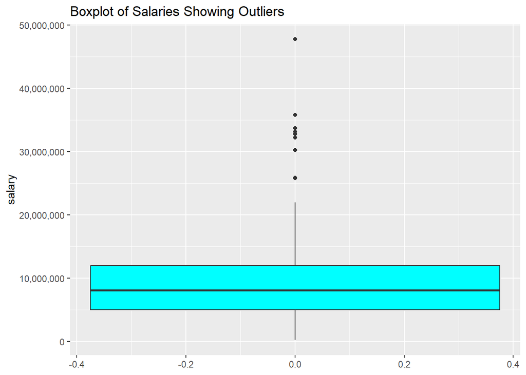

```r
# Boxplot to visualize outliers
ggplot(salary_data, aes(y = salary)) +
  geom_boxplot(fill = "cyan") +
  scale_y_continuous(labels = scales::comma) +
  labs(title = "Boxplot of Salaries Showing Outliers")
```

Now, we programmatically remove data points where the salary is above $Q3 + 1.5 \times IQR$.

```r
Q1 <- quantile(salary_data$salary, 0.25)
Q3 <- quantile(salary_data$salary, 0.75)
IQR <- Q3 - Q1
upper_bound <- Q3 + 1.5 * IQR

# Create a new dataframe without outliers
trimmed_data <- salary_data %>% filter(salary <= upper_bound)

cat("Original number of rows:", nrow(salary_data), "\n")
```

```
## Original number of rows: 607
```

```r
cat("Number of rows after removing outliers:", nrow(trimmed_data), "\n")
```

```
## Number of rows after removing outliers: 597
```

```r
cat(nrow(salary_data) - nrow(trimmed_data), "outliers were removed.\n")
```

```
## 10 outliers were removed.
```

Let’s visualize the salary distribution again with the trimmed data.

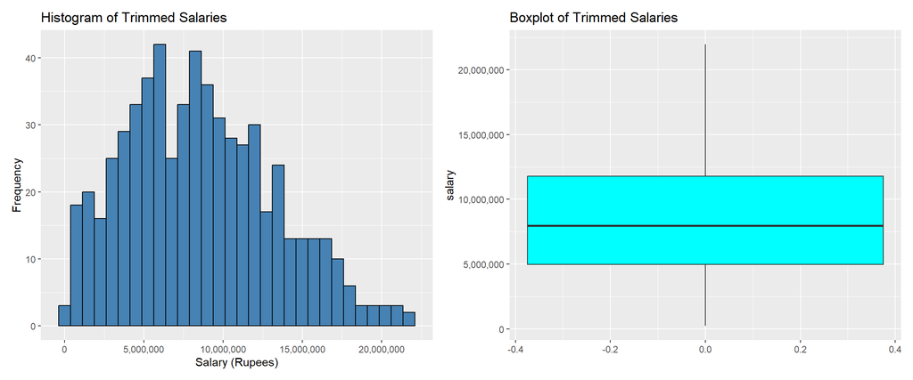

```r
p1_trimmed <- ggplot(trimmed_data, aes(x = salary)) +
  geom_histogram(bins = 30, fill = "steelblue", color = "black") +
  scale_x_continuous(labels = scales::comma) +
  labs(title = "Histogram of Trimmed Salaries", x = "Salary (Rupees)", y = "Frequency")

p2_trimmed <- ggplot(trimmed_data, aes(y = salary)) +
  geom_boxplot(fill = "cyan") +
  scale_y_continuous(labels = scales::comma) +
  labs(title = "Boxplot of Trimmed Salaries")

p1_trimmed + p2_trimmed
```

The distribution of the trimmed salary data is much less skewed and more suitable for linear modeling.

## 3.3. Salary vs. Key Predictors

We will now explore the relationship between salary and key categorical features using boxplots.

### 3.3.1. Statistical Test: ANOVA

To statistically verify the importance of these predictors, we will use an **Analysis of Variance (ANOVA)** test. ANOVA tests whether the mean salary is significantly different across the levels of a categorical variable. A very small p-value (typically < 0.05) indicates that the variable is a significant predictor of salary.

```r
# ANOVA test for Experience Level
summary(aov(salary ~ experience, data = trimmed_data))
```

```
##              Df    Sum Sq   Mean Sq F value Pr(>F)
## experience    3 3.760e+15 1.253e+15   80.98 <2e-16 ***
## Residuals   593 9.178e+15 1.548e+13
## ---
## Signif. codes:  0 '***' 0.001 '**' 0.01 '*' 0.05 '.' 0.1 ' ' 1
```

The p-value is extremely small (`< 2e-16`), confirming that **experience level** is a highly significant factor in determining salary.

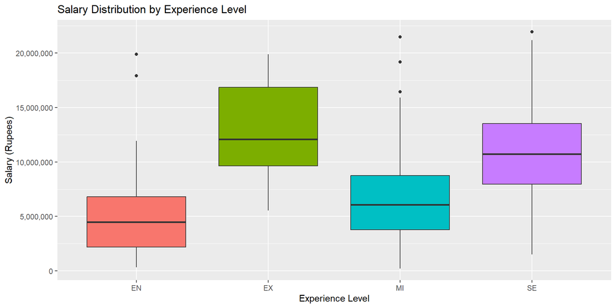

```r
ggplot(trimmed_data, aes(x = experience, y = salary, fill = experience)) +
  geom_boxplot() +
  scale_y_continuous(labels = scales::comma) +
  labs(title = "Salary Distribution by Experience Level",
       x = "Experience Level", y = "Salary (Rupees)") +
  theme(legend.position = "none")
```

### 3.3.2. Company Size

```r
# ANOVA test for Company Size
summary(aov(salary ~ company_size, data = trimmed_data))
```

```
##               Df    Sum Sq   Mean Sq F value   Pr(>F)
## company_size   2 7.226e+14 3.613e+14   17.57 3.87e-08 ***
## Residuals    594 1.222e+16 2.057e+13
## ---
## Signif. codes:  0 '***' 0.001 '**' 0.01 '*' 0.05 '.' 0.1 ' ' 1
```

The p-value is also very small, confirming that **company size** is a significant predictor.

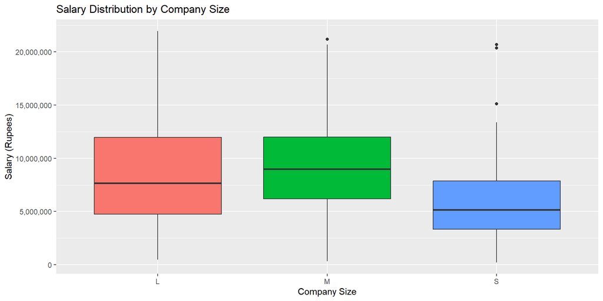

```r
ggplot(trimmed_data, aes(x = company_size, y = salary, fill = company_size)) +
  geom_boxplot() +
  scale_y_continuous(labels = scales::comma) +
  labs(title = "Salary Distribution by Company Size",
       x = "Company Size", y = "Salary (Rupees)") +
  theme(legend.position = "none")
```

### 3.3.3. Remote Working Ratio

```r
# ANOVA test for Remote Working Ratio
summary(aov(salary ~ remote_working_ratio, data = trimmed_data))
```

```
##                       Df    Sum Sq   Mean Sq F value   Pr(>F)
## remote_working_ratio   2 7.552e+14 3.776e+14   18.41 1.75e-08 ***
## Residuals            594 1.218e+16 2.051e+13
## ---
## Signif. codes:  0 '***' 0.001 '**' 0.01 '*' 0.05 '.' 0.1 ' ' 1
```

The p-value is significant, indicating that the **remote work ratio** also has a statistical relationship with salary.

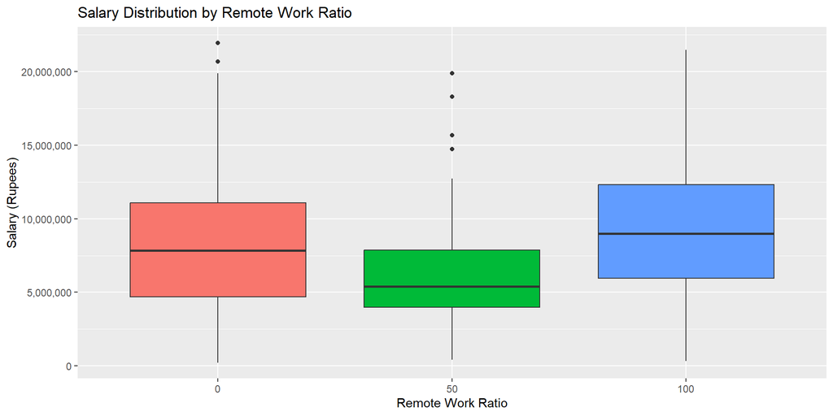

```r
ggplot(trimmed_data, aes(x = remote_working_ratio, y = salary, fill = remote_working_ratio)) +
  geom_boxplot() +
  scale_y_continuous(labels = scales::comma) +
  labs(title = "Salary Distribution by Remote Work Ratio",
       x = "Remote Work Ratio", y = "Salary (Rupees)") +
  theme(legend.position = "none")
```

# 4. Data Preparation for Modeling

## 4.1. Feature Scaling and Splitting

We will predict the `salary`. For regularized regression models, it is standard practice to scale the target variable. We will scale the salary to have a mean of 0 and a standard deviation of 1 (a Z-score).

```r
# Scale the salary and add it as a new column
trimmed_data$salary_scaled <- scale(trimmed_data$salary)

# Set a seed for reproducibility
set.seed(123)

# Create a stratified split of the data
train_indices <- createDataPartition(trimmed_data$salary_scaled, p = 0.8, list = FALSE)
train_data <- trimmed_data[train_indices, ]
test_data  <- trimmed_data[-train_indices, ]

cat("Training set size:", nrow(train_data), "\n")
```

```
## Training set size: 479
```

```r
cat("Testing set size:", nrow(test_data), "\n")
```

```
## Testing set size: 118
```

## 4.2. One-Hot Encoding

Linear models require all predictor variables to be numeric. We will use **one-hot encoding** to convert our factor variables into a set of binary (0/1) columns. We will define the encoding scheme based on the training data and apply the same scheme to the test data to prevent data leakage.

```r
# We will model salary based on all other variables
# Note: We exclude the original 'salary' column now that we have 'salary_scaled'
dummy_model <- dummyVars(salary_scaled ~ . - salary, data = train_data)

# Apply the encoding to the training and test data
train_processed <- as.data.frame(predict(dummy_model, newdata = train_data))
test_processed <- as.data.frame(predict(dummy_model, newdata = test_data))

# Add the target variable back to the processed dataframes
train_processed$salary_scaled <- train_data$salary_scaled
test_processed$salary_scaled <- test_data$salary_scaled
```

# 5. Model Training

```r
# Set up cross-validation
ctrl <- trainControl(method = "cv", number = 10)
```

## 5.1. Model 1: Baseline Linear Regression (LM)

```r
set.seed(123)
lm_model <- train(salary_scaled ~ .,
                  data = train_processed,
                  method = "lm",
                  trControl = ctrl)
```

## 5.2. Model 2: Ridge Regression (Alpha = 0)

Ridge regression is excellent for handling multicollinearity by shrinking coefficients.

```r
set.seed(123)
ridge_model <- train(salary_scaled ~ .,
                     data = train_processed,
                     method = "glmnet",
                     trControl = ctrl,
                     tuneGrid = expand.grid(alpha = 0, # Ridge
                                            lambda = 10^seq(-3, 1, length = 100)))
```

## 5.3. Model 3: Lasso Regression (Alpha = 1)

Lasso regression performs automatic feature selection by forcing the coefficients of unimportant features to exactly zero.

```r
set.seed(123)
lasso_model <- train(salary_scaled ~ .,
                     data = train_processed,
                     method = "glmnet",
                     trControl = ctrl,
                     tuneGrid = expand.grid(alpha = 1, # Lasso
                                            lambda = 10^seq(-4, -1, length = 100)))
```

## 5.4. Model 4: Elastic Net Regression

Elastic Net is a hybrid of Ridge and Lasso, getting the benefits of both. We will let `caret` tune both the `alpha` and `lambda` hyperparameters.

```r
set.seed(123)
elastic_model <- train(salary_scaled ~ .,
                       data = train_processed,
                       method = "glmnet",
                       trControl = ctrl,
                       tuneLength = 10) # caret will pick 10 combinations of alpha/lambda
```

## 5.5. Model 5: XGBoost

Here we will train an XGBoost (Extreme Gradient Boosting) model. This is a powerful tree-based model known for its high performance, as it can capture complex non-linear patterns and feature interactions automatically.

```r
set.seed(123)
xgb_model <- train(salary_scaled ~ .,
                   data = train_processed,
                   method = "xgbTree",
                   trControl = ctrl,
                   tuneLength = 4) # Caret will search 4 combinations of hyperparameters
```

[output not shown]

[output cut: 1865 more lines]

[output not shown]

# 6. Model Evaluation and Comparison

Now we evaluate the models on the unseen **test data**. We will use two key metrics: **RMSE (Root Mean Squared Error):** Measures the average prediction error in the original units of the target variable. Lower is better. **R-squared:** Represents the proportion of variance in the target variable that is predictable from the features. Higher is better (closer to 1).

```r
# Predictions for the first five models
pred_lm <- predict(lm_model, newdata = test_processed)
pred_ridge <- predict(ridge_model, newdata = test_processed)
pred_lasso <- predict(lasso_model, newdata = test_processed)
pred_elastic <- predict(elastic_model, newdata = test_processed)
pred_xgb <- predict(xgb_model, newdata = test_processed)

# Calculate metrics
metrics <- data.frame(
  Model = c("Linear Regression", "Ridge", "Lasso", "Elastic Net", "XGBoost"),
  RMSE = c(RMSE(pred_lm, test_processed$salary_scaled),
           RMSE(pred_ridge, test_processed$salary_scaled),
           RMSE(pred_lasso, test_processed$salary_scaled),
           RMSE(pred_elastic, test_processed$salary_scaled),
           RMSE(pred_xgb, test_processed$salary_scaled)),
  Rsquared = c(R2(pred_lm, test_processed$salary_scaled),
               R2(pred_ridge, test_processed$salary_scaled),
               R2(pred_lasso, test_processed$salary_scaled),
               R2(pred_elastic, test_processed$salary_scaled),
               R2(pred_xgb, test_processed$salary_scaled))
)

# Print the sorted results table
metrics %>% arrange(RMSE) %>% knitr::kable(digits = 4, caption = "Initial Model Performance Comparison")
```

Initial Model Performance Comparison

| Model | RMSE | Rsquared |
| --- | --- | --- |
| XGBoost | 0.6911 | 0.5683 |
| Lasso | 0.7039 | 0.5545 |
| Elastic Net | 0.7156 | 0.5383 |
| Ridge | 0.7396 | 0.5073 |
| Linear Regression | 0.7841 | 0.4752 |

## 6.2. Feature Importance

Let’s look at the most important features identified by our best model among the linear ones, Lasso and the overall winner XGBoost.

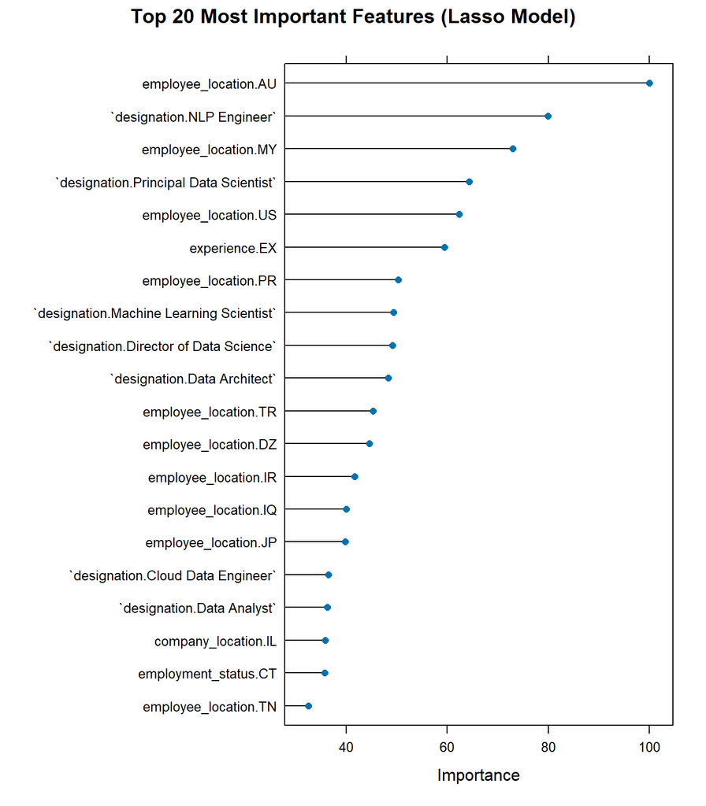

```r
plot(varImp(lasso_model), top = 20, main = "Top 20 Most Important Features (Lasso Model)")
```

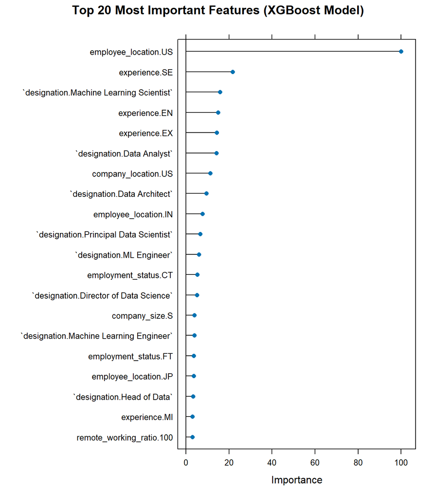

```r
plot(varImp(xgb_model), top = 20, main = "Top 20 Most Important Features (XGBoost Model)")
```

As expected from our EDA, features related to **designation**, **experience level** (especially `EX` for executive), and **location** are the most influential predictors of salary.

## 6.3. Residuals Plot

A residuals plot helps diagnose the performance of the best model. It plots the prediction errors (residuals) against the predicted values. A good model will have a random scatter of points around the zero line.

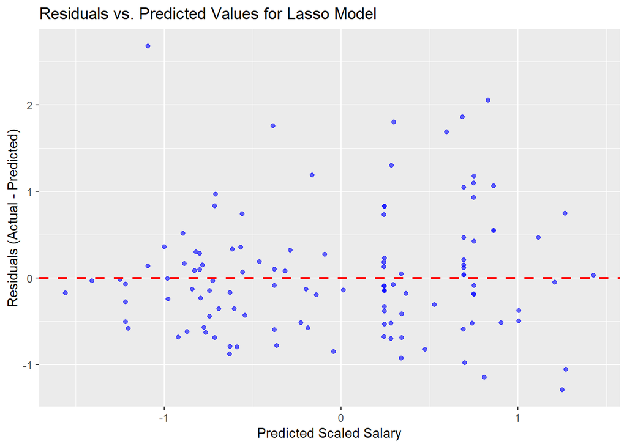

```r
# Create a dataframe for plotting residuals
residuals_df <- data.frame(
  Predicted = pred_lasso,
  Actual = test_processed$salary_scaled,
  Residuals = test_processed$salary_scaled - pred_lasso
)

ggplot(residuals_df, aes(x = Predicted, y = Residuals)) +
  geom_point(alpha = 0.6, color = "blue") +
  geom_hline(yintercept = 0, linetype = "dashed", color = "red", size = 1) +
  labs(title = "Residuals vs. Predicted Values for Lasso Model",
       x = "Predicted Scaled Salary",
       y = "Residuals (Actual - Predicted)")
```

The residuals are scattered randomly around the zero line with no obvious patterns, which indicates that our model is a good fit and does not have significant systematic biases.

# 7. Further Improvements and Conclusion

# 8. Experiment: Improving the Lasso Model

After seeing the superior performance of XGBoost, a natural question arises: can we improve our best linear model (Lasso) to get closer to XGBoost’s accuracy? We can try by manually adding an **interaction term** to help the linear model capture some of the non-linear relationships in the data.

## 8.1. Training the Improved Lasso Model

Here we will train the Improved Lasso model with an interaction between `experience.SE` and `designation.Data.Scientist`.

```r
# This is the code you cut from Section 5
set.seed(123)
improved_lasso_model <- train(
  salary_scaled ~ . + experience.SE:`designation.Data Scientist`,
  data = train_processed,
  method = "glmnet",
  trControl = ctrl,
  tuneGrid = expand.grid(alpha = 1,
                         lambda = 10^seq(-4, -1, length = 50))
)
```

## 8.2. Lasso vs. Improved Lasso vs. XGBoost

Let’s make predictions with this new model and compare it directly to the original Lasso and the top-performing XGBoost model.

```r
# Make prediction with the new model
pred_improved_lasso <- predict(improved_lasso_model, newdata = test_processed)

# Create a final, focused comparison table
showdown_metrics <- data.frame(
  Model = c("Lasso (Original)", "Improved Lasso (Interactions)", "XGBoost"),
  RMSE = c(RMSE(pred_lasso, test_processed$salary_scaled),
           RMSE(pred_improved_lasso, test_processed$salary_scaled),
           RMSE(pred_xgb, test_processed$salary_scaled)),
  Rsquared = c(R2(pred_lasso, test_processed$salary_scaled),
               R2(pred_improved_lasso, test_processed$salary_scaled),
               R2(pred_xgb, test_processed$salary_scaled))
)

# Print the final showdown results
showdown_metrics %>% arrange(RMSE) %>% knitr::kable(digits = 4, caption = "Final Model Showdown")
```

Final Model Showdown

| Model | RMSE | Rsquared |
| --- | --- | --- |
| XGBoost | 0.6911 | 0.5683 |
| Improved Lasso (Interactions) | 0.7013 | 0.5578 |
| Lasso (Original) | 0.7039 | 0.5545 |

## 8.3. Experiment Conclusion

The experiment was a success. Adding a single, targeted interaction term did improve the Lasso model’s performance, lowering its RMSE and increasing its R-squared.

However, while valuable, this manual improvement was not enough to close the gap with XGBoost. This highlights the primary strength of advanced algorithms like XGBoost: they can discover hundreds of complex interactions and non-linear patterns automatically, leading to a higher level of predictive accuracy.